# Explore relational topic model

Joyce Hsiao

2015-09-25

We use the relational topic model due to Jonatha Huang to uncover underlying micriobiome clusters in the HMP data, in particular the crease subset. Specifically, we fit a topic model with the constraint that some samples come from the sample individuals. The expectation is that the samples belong to the same individuals are more likely to be grouped into the same clusters as opposed to samples that come from two different individuals.

Note that in the literature, left hand generally is found to have very little in common with right hand in the microbial community composition. However, I suspect that after fitting a model with constraints, we will find more similarities between right and left hand. Furthermore, do microbial communities share more similarities within and individual or between an individual??

## Set up

```r
library(metagenomeSeq)
library(maptpx)
#library(tsne)))
#library(qtlcharts)
library(ggplot2)
library(lda)
```

## Prepare data

```r
load(file = '../data/HMPvs35_nt100_MRexperiment.rdata')

hmp <- filterData(hmp, present=10)

counts <- t(MRcounts(hmp, norm=TRUE, log = FALSE))

metadata <- pData(hmp)
otu_data <- featureData(hmp)

counts_crease <- counts[which(metadata$HMPbodysubsite=="Right_Retroauricular_crease" |
                               metadata$HMPbodysubsite=="Left_Retroauricular_crease"), ]
metadata_crease <- metadata[which(metadata$HMPbodysubsite=="Right_Retroauricular_crease" |
                               metadata$HMPbodysubsite=="Left_Retroauricular_crease"), ]
table(metadata_crease$HMPbodysubsite)
```

```
##
##  Left_Retroauricular_crease Right_Retroauricular_crease
##                         306                         321
```

Indiviudal labels

```r
person_label <- sapply(1:dim(metadata_crease)[1], function(x)
                         strsplit( metadata_crease$Description[x],"_")[[1]][8] )

# Compare hostsubject id and also description
which(person_label == "763435843")
```

```
## [1]   1 156
```

```r
cbind(person_label, metadata_crease$hostsubjectid)[c(1,156), ]
```

```
##      person_label
## [1,] "763435843"  "241763"
## [2,] "763435843"  "241763"
```

```r
length(unique(metadata_crease$hostsubjectid))
```

```
## [1] 193
```

```r
length(unique(person_label))
```

```
## [1] 193
```

## Relationtional topic model analysis

Prepare input

```r
## Choose only samples with 1 or 0 link in the data
input_link <- lapply(1:length(metadata_crease$hostsubjectid), function(per_person) {
                          id <- metadata_crease$hostsubjectid[per_person]
                          exp <- metadata_crease$EXPERIMENTACCESSION[per_person]
                          pair <- which(metadata_crease$hostsubjectid == id)
                          pair[pair != per_person]
                          })
ii_subset <- which(sapply(input_link, function(xx) length(xx) < 2))

# counts entry needs to be a list
counts_crease <- round(counts_crease)
counts_crease_subset <- counts_crease[ii_subset, ]
metadata_crease_subset <- metadata_crease[ii_subset, ]


input_crease_subset <- lapply(1:nrow(counts_crease_subset), function(per_person) {
                          rbind(as.integer( c(0: (ncol(counts_crease_subset) - 1 ) ) ),
                                as.integer(counts_crease_subset[per_person, ] ) )
                          })
input_link_subset <- lapply(1:length(metadata_crease_subset$hostsubjectid), function(per_person) {
                          id <- metadata_crease_subset$hostsubjectid[per_person]
                          exp <- metadata_crease_subset$EXPERIMENTACCESSION[per_person]
                          pair <- which(metadata_crease_subset$hostsubjectid == id)
                          as.integer(pair[pair != per_person] - 1)
                          })
input_genes <- colnames(counts_crease_subset)

stopifnot (max(unlist(input_link_subset)) == length(input_crease_subset) - 1)
stopifnot( min(unlist(input_link_subset)) == 0)
stopifnot( min(input_crease_subset[[1]] )  == 0)
```

Fit relational topic model

```r
if (!file.exists("../rdas/relation-topics-hmp.rda")) {
  rtm.model <- lapply(2:5, function(per_clust) {
                            rtm.collapsed.gibbs.sampler(input_crease_subset,
                                                        input_link_subset,
                                                        per_clust,
                                                        vocab = input_genes,
                                                        num.iterations = 35,
                                                        alpha = 0.1,
                                                        eta = 0.1, beta = 3)
                        })
save(rtm.model, file = "../rdas/relation-topic-hmp.rda")
} else {
  load("../rdas/relation-topic-hmp.rda")
}
```

```r
# document_sums: each entry is a numeric proportional
# to the probability of seeing a topic (row) conditioned on the document column

topic_probs <- lapply(1:length(rtm.model), function(per_clust) {
                      t(t(rtm.model[[per_clust]]$document_sums)/
                            colSums(rtm.model[[per_clust]]$document_sums))
                      })
dim(topic_probs[[1]])
```

```
## [1]   2 178
```

Topic results

- When assume 2 underlying clusters

```r
# Find the maximum topic probability for each document
ii_topic <- apply(rtm.model[[1]]$document_sums, 2, which.max)
unique_subject <- table(metadata_crease_subset$hostsubjectid)
unique_subject <- names(unique_subject)[unique_subject==2]
subjects <- metadata_crease_subset$hostsubjectid

topic_match_sort <- lapply(unique_subject, function(xx) {
    ii_subject <- which(subjects %in% xx)
    ii_topic[ii_subject]
})
#topic_match_sort

table(sapply(topic_match_sort, function(xx) xx[1] == xx[2]))
```

```
##
## FALSE  TRUE
##    27    50
```

Most individuals have similar micriobial community on the left versus on the right hand.

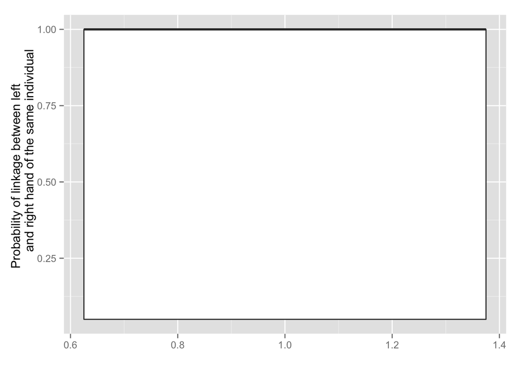

```r
edges <- links.as.edgelist(input_link_subset)
rtm_similarity <- predictive.link.probability(edges,
                                              rtm.model[[1]]$document_sums,
                                              0.1, 3)

## Compute the number of linked samples (edge) for each sample (node)
per_sample_edges <- table(factor(edges[ ,1],
                                 levels = 1:dim(rtm.model[[1]]$document_sums)[2]) )

## Compute which gene (topic) is most expressed by the samples
max_gene <- apply(rtm.model[[1]]$document_sums, 2, which.max)

qplot(data = data.frame(x = 1, y = rtm_similarity), x = x, y = y, geom = "boxplot",
      xlab = "",
      ylab = "Probability of linkage between left
              and right hand of the same individual")
```

- When assume 5 underlying clusters

```r
# Find the maximum topic probability for each document
ii_topic <- apply(rtm.model[[4]]$document_sums, 2, which.max)
unique_subject <- table(metadata_crease_subset$hostsubjectid)
unique_subject <- names(unique_subject)[unique_subject==2]
subjects <- metadata_crease_subset$hostsubjectid

topic_match_sort <- lapply(unique_subject, function(xx) {
    ii_subject <- which(subjects %in% xx)
    ii_topic[ii_subject]
})
#topic_match_sort

table(sapply(topic_match_sort, function(xx) xx[1] == xx[2]))
```

```
##
## FALSE  TRUE
##    30    47
```

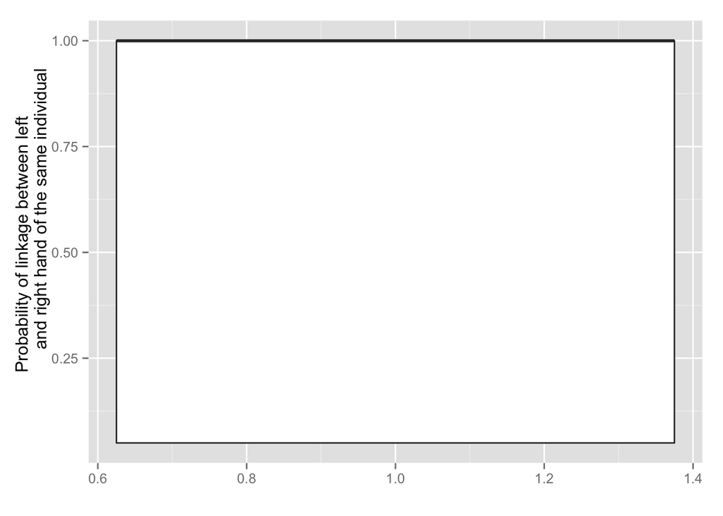

```r
edges <- links.as.edgelist(input_link_subset)
rtm_similarity <- predictive.link.probability(edges,
                                              rtm.model[[4]]$document_sums,
                                              0.1, 3)
qplot(data = data.frame(x = 1, y = rtm_similarity), x = x, y = y, geom = "boxplot",
      xlab = "",
      ylab = "Probability of linkage between left
              and right hand of the same individual")
```

Structure plot

- Arranged by left or right hand

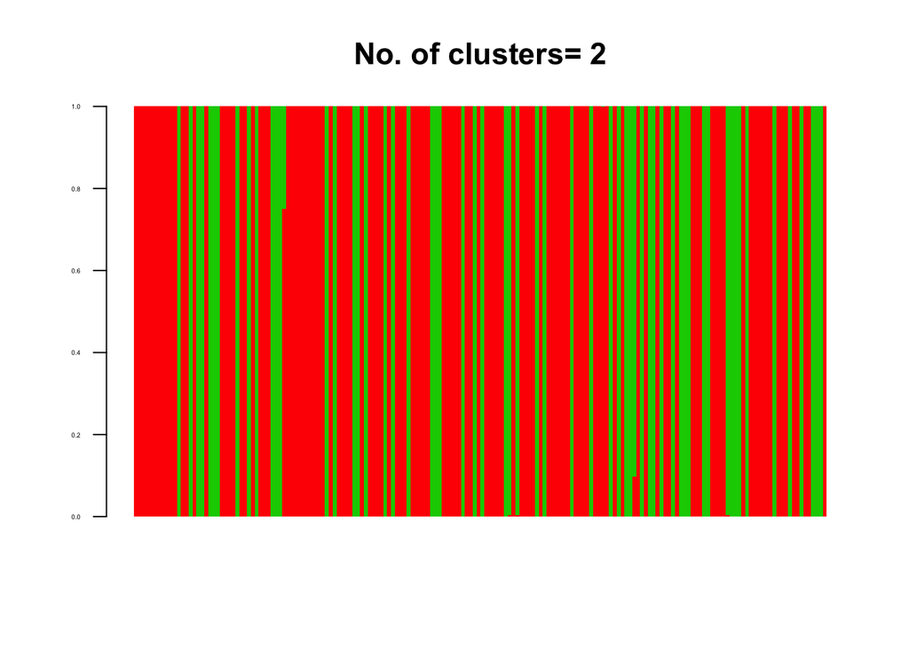

```r
nclust <- 2:5
ii_order <- order(metadata_crease_subset$HMPbodysubsite)
for (per_clust in 1:1) {
      clust <- nclust[per_clust]
      docweights <- topic_probs[[per_clust]]
      #ii_order <- order(docweights[1, ], docweights[2, ])
      docweights_ordered <- docweights[ , ii_order]
      barplot( docweights_ordered,
               col = 2:(clust+1), axisnames = F,
               space = 0, border=NA,
               main = paste("No. of clusters=", clust), las = 1,
               ylim = c(0,1), cex.axis = 0.3, cex.main=1.4)
#      labels <- match(unique(type_ordered[,1]), type_ordered[,1])
#       abline(v=labels-1, lwd =3)
#       labels_low <- labels-1
#       labels_up <- c(labels_low[2:length(labels_low)], dim(docweights_ordered)[1])
#       mid_point <- labels_low +0.5*(labels_up-labels_low)
#       axis(1, at = mid_point, unique(type_ordered[,1]), las = 2, cex.axis=0.3)
}
```

PCA plot

```r
ii_label <- apply(topic_probs[[1]], 2, which.max)

pca_crease <- prcomp(log10(counts_crease_subset + 1) %*% t(log10(counts_crease_subset + 1)))

library(qtlcharts)
iplot(pca_crease$x[,1], pca_crease$x[,2],
      as.numeric(as.factor(ii_label)), ii_label)
```

```
## Set screen size to height=700 x width=1000
```

[interactive chart not shown]

```r
iplot(pca_crease$x[,1], pca_crease$x[,2],
      as.numeric(as.factor(metadata_crease_subset$hostsubjectid)),
      metadata_crease_subset$hostsubjectid)
```

[interactive chart not shown]